# First Final of Final Semester: Economic Data and Version Control Woes

Ashley Brockway, Olivia Roberts, and Justin Tienken-Harder

12/02/2020

# Introduction

## Data Description

The source of our data is the World Development Index found on the World Bank’s data explorer. The WDI was chosen because of it’s expansive time series data for countries across the world. The variables explored in this project include:

- Unemployment, total (% of total labor force) (national estimate)
  - The percent share of the labor force in US that is out of work but seeking and available for work
- Share of youth not in education, employment or training, total (% of youth population)
  - The share of youth not in education, employment or training (also known as “the NEET rate”) conveys the number of young persons not in education, employment or training as a percentage of the total youth population, which is defined as individuals aged 15-24
- GDP (current USD)
  - Gross Domestic Product measured in Current USD

This time series data has a yearly frequency. Total unemployment and GDP is observed from 1960-2019 (60 years), while share of youth not participating in education, employment, or training is observed from 1994-2019 (26 years). Thus, when working with the time series forecasting and fitting, 60 observations are used, but only 26 are used for the dynamic regression.

## Project Objectives

With our time series data we aim to:  
1. Forecast US GDP and compare results using multiple techniques  
2. Implement the Box-Jenkins method to model the data with ARIMA(p,d,q) and compare with auto.arima, and validate the best model looking at metrics  
3. Analyze how share of youth not in education/training (share of youth NEET) explains unemployment rate using dynamic regression after confirming that the assumptions of linear regression are violated

Our forecasts and analysis gives us the opportunity to predict future GDP and explore how relationships between economic indicators influence each other.

## Preprocessing

```r
wdi_data <- read.csv('WDI2.csv', na.strings = c("..")) %>%
  select(Country=Country.Code, Value=Series.Name, contains("X")) %>%
  filter(Country=="USA") %>%
  data.frame()

wdi1 <- wdi_data[c(10, 11, 15, 16, 17, 18),]
wdi2 <- t(wdi_data)

rownames(wdi2) <- c("Country", "Value",1960:2019)
colnames(wdi2) <- wdi2[2,]

wdi <- wdi2[-(1:2),]
#wdi <- wdi %>% as.data.frame() %>%  mutate_each(funs(as.numeric))
row.names(wdi) <- row.names(wdi2)[3:length(row.names(wdi2))]
wdi_ts <- ts(wdi, start = 1960)
```

# Forecast US GDP growth

## Variance Stabilization:

### Constant Variance? Let us see…

We first must determine if our data has non-constant variance (through time). We will draw a one standard deviation band around our data calculated from a moving window. If our data has constant variance, then we should expect this band to be uniform width across time. Further, we’ll look at a plot of the variance of our data over time, we should expect this plot to have an approximately constant mean across time, and for the variance of this plot to be quite small.

You can change the window size manually or animate the graph to see how increasing the window size effects the variance of US GDP.

[figure not shown]

### What stabilization method shall we use?

It should be clear that we need to transform our data because the variance is not constant throughout time. Here’s a comparison of the automatically selected BoxCox transformation (lambda is automatically selected) versus a log transformation:

[figure not shown]

Notice how the variance through time is very close to 0.9 across time for the log transformation. This transformation has fixed the non-constant variance of the data. The box-cox transformation must use a different criteria than the variance of a moving window, but part of it could be due to the scale difference between the two.

## Forecasting

Here we’ll be looking at four different forecasting methods:

### Naive

As you can see, due to the log transform of our data, the 95% and 80% confidence intervals have been skewed towards larger predictions (i.e., the larger the time, the larger variance in positive predictions). However, it’s important to check the residuals of our forecast!

[figure not shown]

However, it’s important to check the residuals of our forecast! As you can see below, we do not have approximately white-noise auto-correlations. Further, our residuals have constantish variance and mean. Notably, the residuals are approximately normally distributed, but they are not centered at zero which indicates that a drift model might be better. Therefore, we should not really trust the confidence intervalse on the predictions.

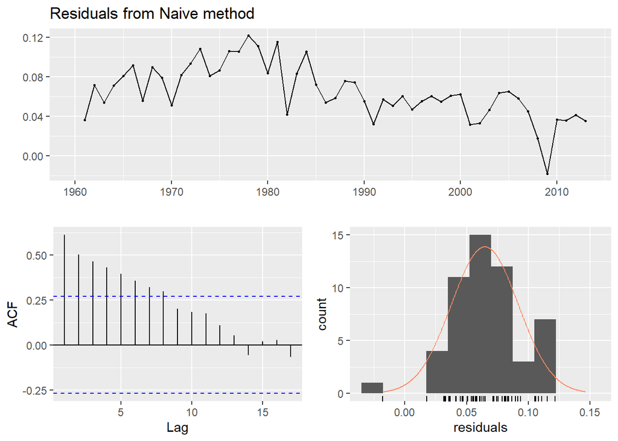

```
##
##  Ljung-Box test
##
## data:  Residuals from Naive method
## Q* = 93.554, df = 10, p-value = 9.992e-16
##
## Model df: 0.   Total lags used: 10
```

### Drift

[figure not shown]

```r
#, include = F}
drift <- rwf(less, drift = TRUE , lambda = lamb, h = 6)
```

It’s important to check to see if our drift parameter is statistically significant. In this case, the drift parameter is more than two standard errors from zero, so it’s statistically significant. Further, with such a small drift of $\mu = 0.0647$, one might be tricked into thinking it’s not practically significant; however, this is on the log-scale. For one step in time, the next value is on average, the previous value multiplied by 1.066 which is quite significant.

```r
summary(rwf(less, lambda = 0, drift = T, h=6))
```

```
##
## Forecast method: Random walk with drift
##
## Model Information:
## Call: rwf(y = less, h = 6, drift = T, lambda = 0)
##
## Drift: 0.0647  (se 0.0037)
## Residual sd: 0.0272
##
## Error measures:
##                        ME         RMSE          MAE        MPE     MAPE
## Training set -90562739765 254696913143 137917721531 -0.0362307 2.134682
##                   MASE      ACF1
## Training set 0.4358923 0.7028857
##
## Forecasts:
##      Point Forecast        Lo 80        Hi 80        Lo 95        Hi 95
## 2014   1.790723e+13 1.729467e+13 1.854149e+13 1.697892e+13 1.888629e+13
## 2015   1.910466e+13 1.817862e+13 2.007786e+13 1.770672e+13 2.061296e+13
## 2016   2.038216e+13 1.916809e+13 2.167313e+13 1.855495e+13 2.238930e+13
## 2017   2.174508e+13 2.024346e+13 2.335809e+13 1.949100e+13 2.425985e+13
## 2018   2.319914e+13 2.140025e+13 2.514925e+13 2.050515e+13 2.624709e+13
## 2019   2.475044e+13 2.263856e+13 2.705933e+13 2.159455e+13 2.836754e+13
```

Finally, we’ll take a look at the residuals below. As you can see, the residual distribution is now centered around zero; however the auto-correlations don’t resemble white noise – so the confidence intervals are not trustworthy

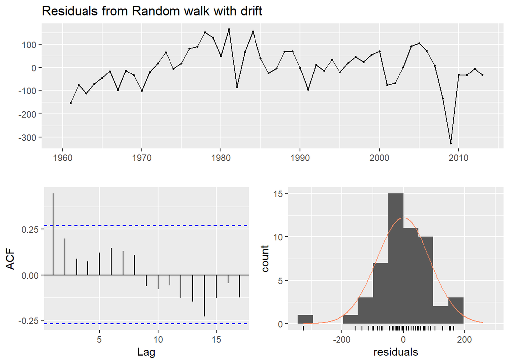

```
##
##  Ljung-Box test
##
## data:  Residuals from Random walk with drift
## Q* = 18.984, df = 9, p-value = 0.02533
##
## Model df: 1.   Total lags used: 10
```

### Seasonal Naive

The data does not appear to have any kind of seasonality. Maybe if the dataset had a frequency of 4 (i.e., quarterly data), we might be able to identify some seasonal components; however, we can still check to see if there is any indication of some non-standard seasonal components (e.g., ever decade). Seeing as how none of the lags greater than one look like the lag-1 plot, we can reasonably presume there aren’t any larger seasonal components.

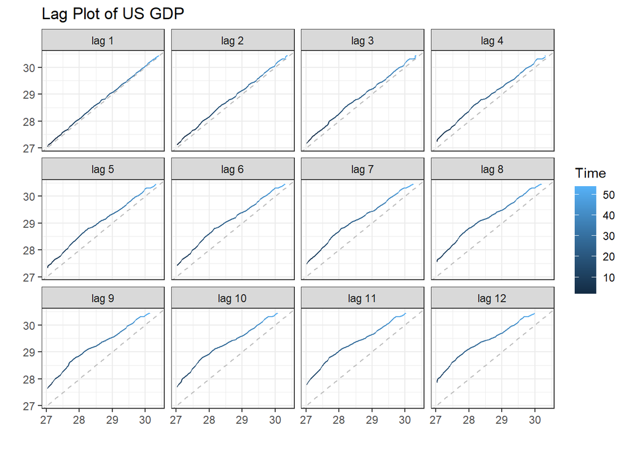

### ARIMA

We’ve already stabilized the variance. The mean does not appear to be constant through time. To double check, we’ll utilize the Kwiatkowski-Phillips-Schmidt-Shin test of stationarity. In this test, the null hypothesis is that our time series is level or trend stationary. We get a p-value of 0.01, in which we reject the null hypothesis – this provides evidence that we need to do some differencing for mean-stabilization.

```
##
##  KPSS Test for Level Stationarity
##
## data:  log(US_GDP)
## KPSS Level = 1.5676, Truncation lag parameter = 3, p-value = 0.01
```

Now we must determine what sort of ARIMA(p,d,q) model to choose from. To do this, we will set d=1 and take a look at the ACF and PACF to make an educated guess at the order of p and q. Further differencing (i.e., d = 2) does improve the variance of the time series, and doesn’t appear to over-difference the data; however, we’ll roll with d=1, but include ARIMA(0,2,1) in the final model comparisons.

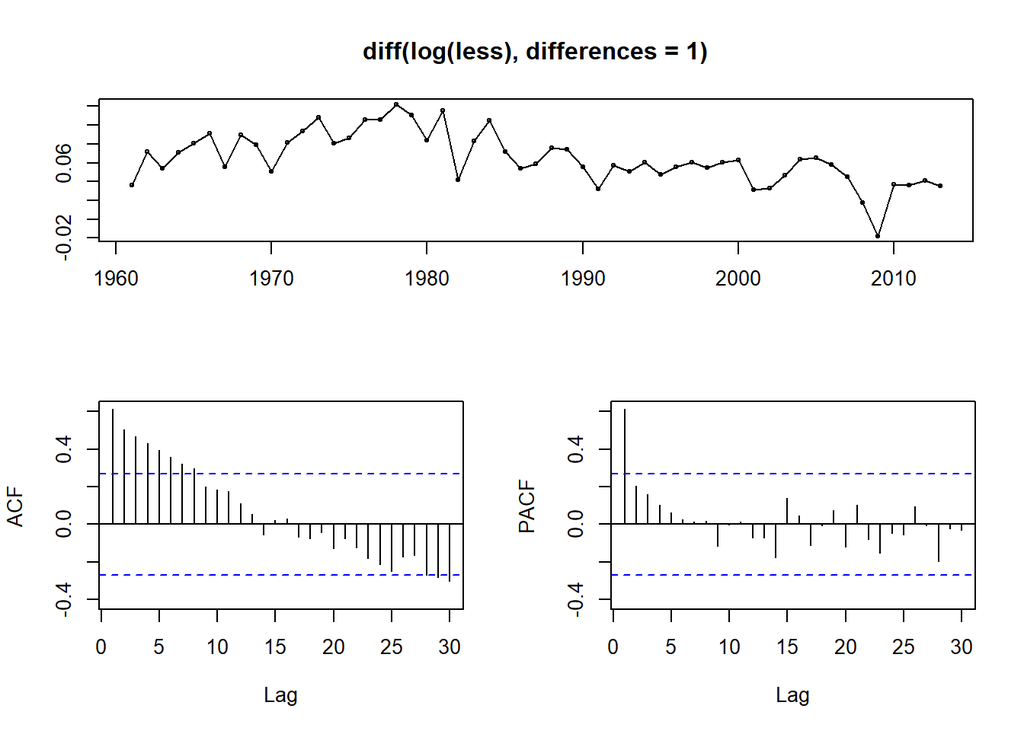

Due to the shapes of the ACF and PACF, we will consider a little bit of AR and a little bit of MA, the best model will likely be ARMA(1,1,1). We’ll do a comparison across all the models (RMSE, MAP, AICc) later.

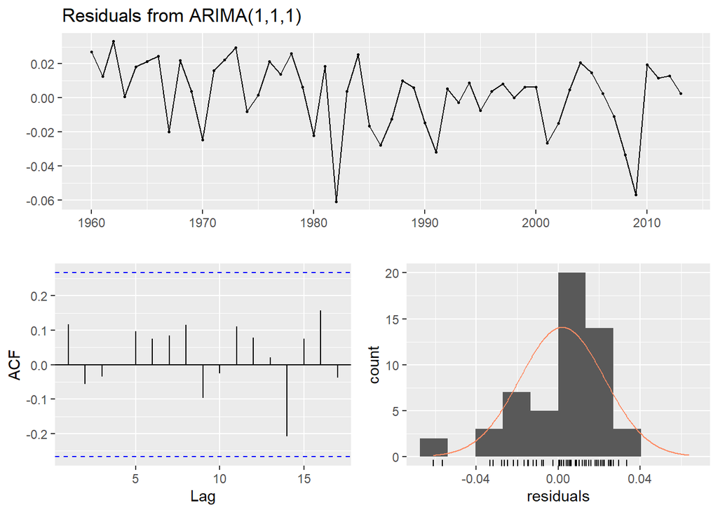

```
##
##  Ljung-Box test
##
## data:  Residuals from ARIMA(1,1,1)
## Q* = 3.9655, df = 8, p-value = 0.8602
##
## Model df: 2.   Total lags used: 10
```

```r
model <- Arima(less, order = c(1,1,1), lambda = 0)
checkresiduals(model)
```

The Ljung-Box test indicates we fail to reject the hypothesis of white-noise residuals. Further, our residuals appear much more normally distributed (centered at 0) than the previous models.

Finally, we’ll take a look at the forecasts.

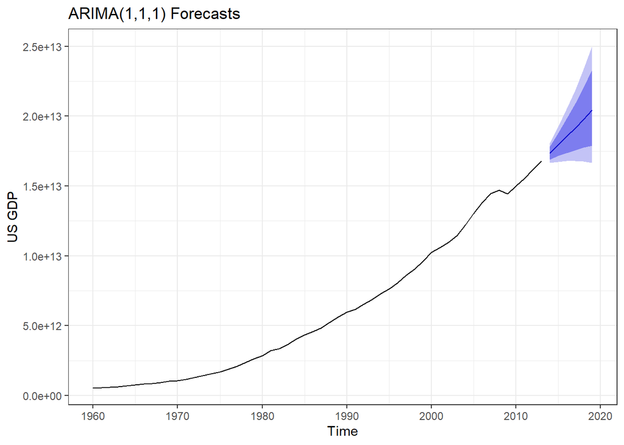

### Model Comparisons

Theorem: Naive Forecasting model is equivalent to a specific ARIMA(p,d,q) model.

Proof:

Consider the modeling equation for the Naive model, and we will transform it into the modeling equation for ARIMA(0,1,0) with no intercept parameter.

$$Y_t = Y_{t-1} + \epsilon_t \sim _{_{i.i.d.}} N(0,\sigma^2) \,\,\,\, (\text{Naive Model}) \\
\iff Y_t-Y_{t-1} = \epsilon_t \sim _{_{i.i.d.}} N(0,\sigma^2) \\
\iff Y^{\prime}_t = \epsilon_t \sim _{_{i.i.d.}} N(0,\sigma^2) \text{ such that } Y^{\prime}_t = Y_t - Y_{t-1}\,\,\,\, \\ (\text{ARIMA(0,1,0) Model})$$

Now we’ll compare Naive, Drift, ARIMA(1,1,1) and some surrounding models through AICc, test RMSE, test MAPE, and cross validation.

[figure not shown]

Let’s take a look at the test set RMSE, MAPE, and the model AICc:

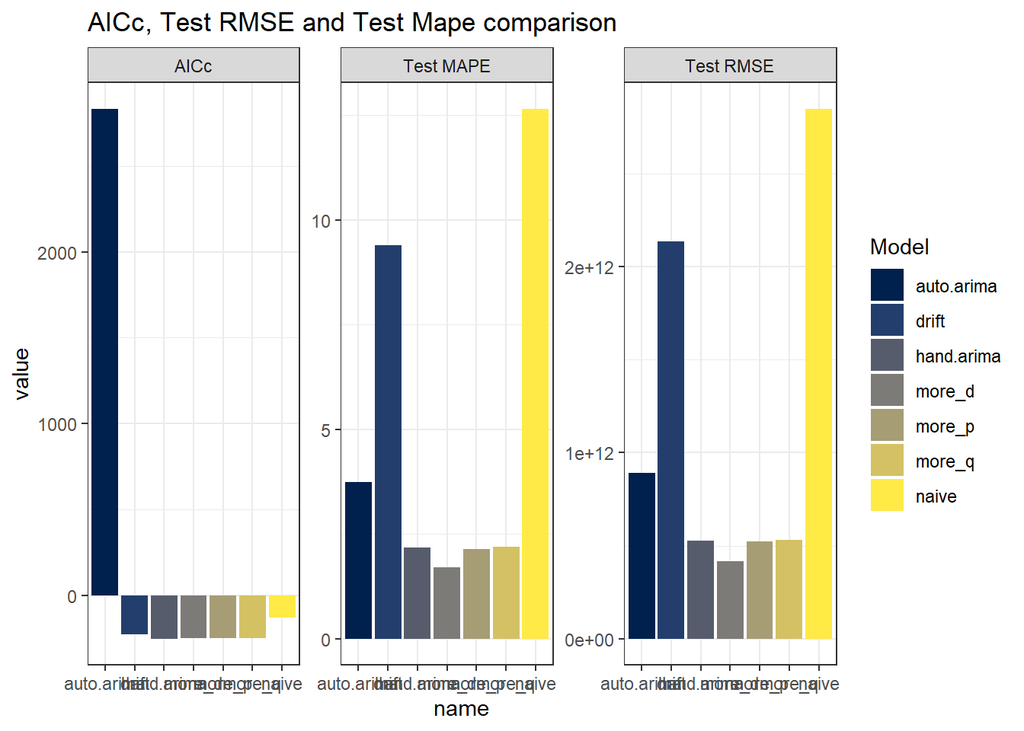

[output not shown]

# Anaylsis of Two Time Series Variables

## Classic Regression

### Correlation between ShareofyouthNEET and Unemployment

The correlation between the share of youth that are not employed, in education or job training and the overall unemployment rate across time is 0.84 The strength of this correlation, as well as the somewhat linear trend depicted in the scatterplot provided, motivates us to further study the plausibility of a significant relationship between the two variables.

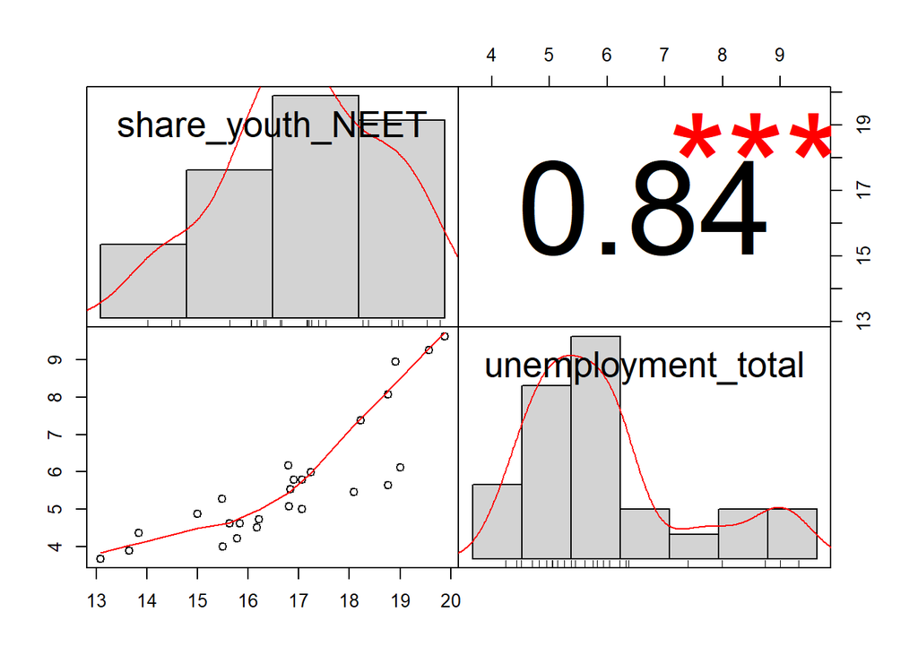

```r
chart.Correlation(regression_data, histogram = TRUE, pch=19)
```

### Classic regression of Unemployment ~ share of youth NEET

The regression of unemployment ~ share of youth NEET results results in a positive statistically significant relationship between share of youth NEET and unemployment. The Resulting $R^2$ value is 0.71. The Best fit line plot backs up the positive relationship seen in the coefficient for the predictor.

```r
lm_fit <- lm(unemployment_total ~ share_youth_NEET, data = regression_data)
summary(lm_fit)
```

```
##
## Call:
## lm(formula = unemployment_total ~ share_youth_NEET, data = regression_data)
##
## Residuals:
##     Min      1Q  Median      3Q     Max
## -1.5989 -0.7124 -0.1191  0.5843  1.5825
##
## Coefficients:
##                  Estimate Std. Error t value Pr(>|t|)
## (Intercept)       -7.2554     1.6938  -4.283 0.000257 ***
## share_youth_NEET   0.7733     0.1004   7.700 6.16e-08 ***
## ---
## Signif. codes:  0 '***' 0.001 '**' 0.01 '*' 0.05 '.' 0.1 ' ' 1
##
## Residual standard error: 0.906 on 24 degrees of freedom
## Multiple R-squared:  0.7119, Adjusted R-squared:  0.6999
## F-statistic: 59.29 on 1 and 24 DF,  p-value: 6.162e-08
```

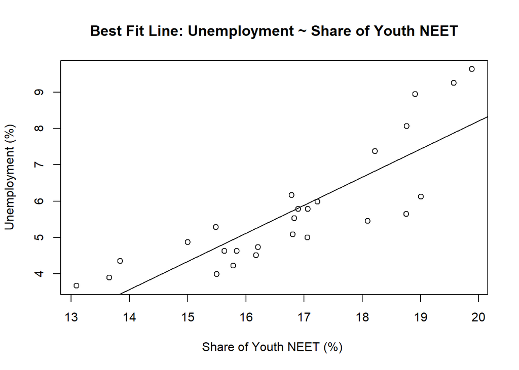

```r
plot( regression_data$share_youth_NEET, regression_data$unemployment_total, main = "Best Fit Line: Unemployment ~ Share of Youth NEET", ylab="Unemployment (%)", xlab="Share of Youth NEET (%) ")
abline(lm_fit)
```

### Full Modeling Equation and Fitted Model Equation

The full modeling equation for the classic regression:

$$unemployment_i \, = \, \beta_0 \, + \, \beta_1youthNEET_i \, + \, \epsilon_i, \\ \epsilon_i \sim _{i.i.d.} N(0, \sigma^2) \\ i \, = \, 1, 2, 3, ..., n$$

$$\hat{unemployment_i} \, = \, - \, 7.3 \, + \, 0.77youthNEET_i$$

### Residuals Diagnostics for Classic Linear Regression

The QQ-norm plot reveals that the residuals are fairly normally distributed, this is verified by the histogram of residuals. While the distribution is not perfectly normal, given that there are only 26 observations of each variable, it can be considered normal enough. The Breusch-Godfrey test results in a p-value of 0.001 which is small enough to reject the null hypothesis and conclude that the residuals are not white noise (i.e. that there is evidence of autocorrelation and serial dependence). The residuals versus time plot also reveals that the residuals are not centered around a constant mean, even though the variance is consistent across time.

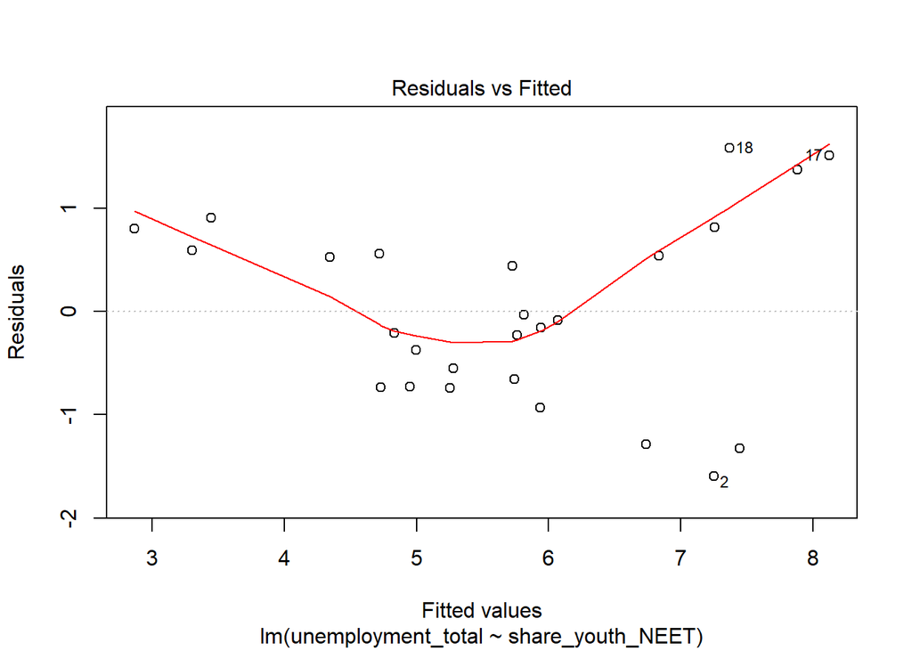

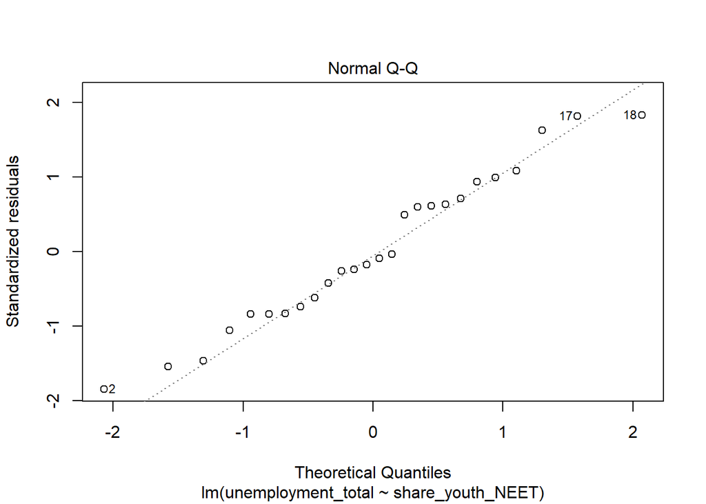

```r
plot(lm_fit, which = c(1:2))
```

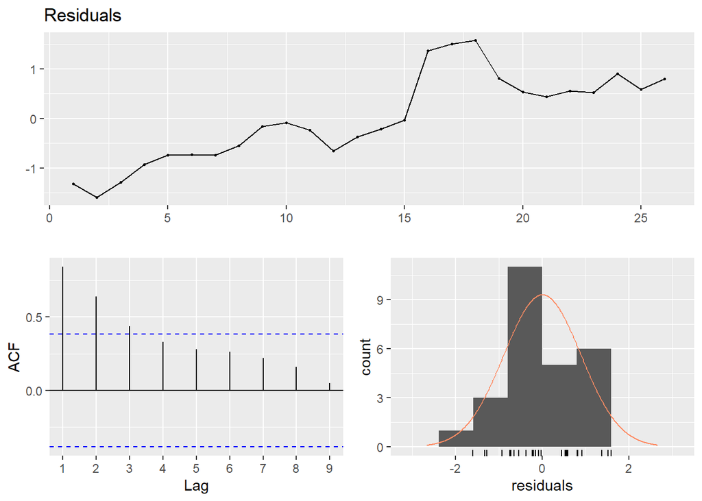

```
##
##  Breusch-Godfrey test for serial correlation of order up to 5
##
## data:  Residuals
## LM test = 19.838, df = 5, p-value = 0.00134
```

```r
checkresiduals(lm_fit)
```

## Dynamic regression

### Motivations to use Dynamic Regression

Due to the residuals being autocorrelated, the $\epsilon_t$ need to be modeled via ARIMA. Running ndiffs() shows it is necessary to perform consecutive differencing for stationarity. The differenced residuals are plotted, and because all autocorrelations are within the white noise bands p and q are both 0. Thus p,d,q = (0, 1, 0).

```r
ndiffs(resid(lm_fit))
```

```
## [1] 1
```

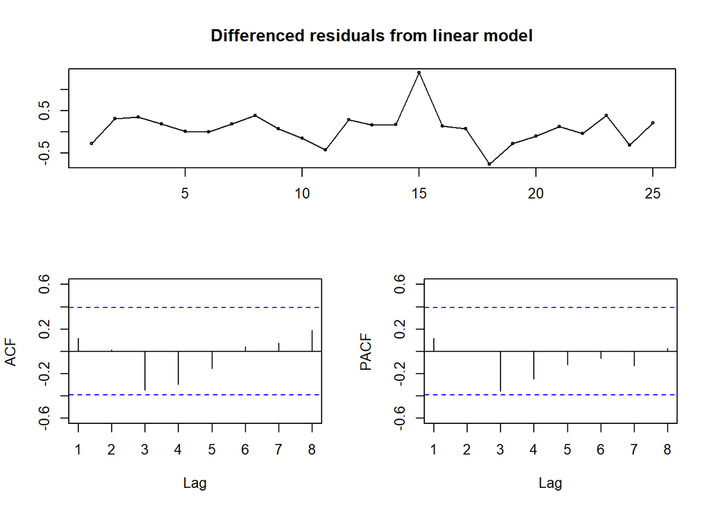

```r
tsdisplay(diff(lm_fit$residuals), main = "Differenced residuals from linear model")
```

### Fitting with auto.arima()

We check the results from auto.arima() to confirm what was established above. Auto-ARIMA also results in p,d,q = (0,1,0). The residuals plots of the fitted model shows a mean of approximately 0, though constant variance is questionable, and a mostly normal distribution of residuals. 100% of autocorrelations are within the white noise bands. A large pvalue is observed from the Ljung-Box test which results in failing to reject the null hypothesis (residuals are white noise) and supports the visual that the residuals are white noise. Thus, the fit is good because the residuals are white noise.

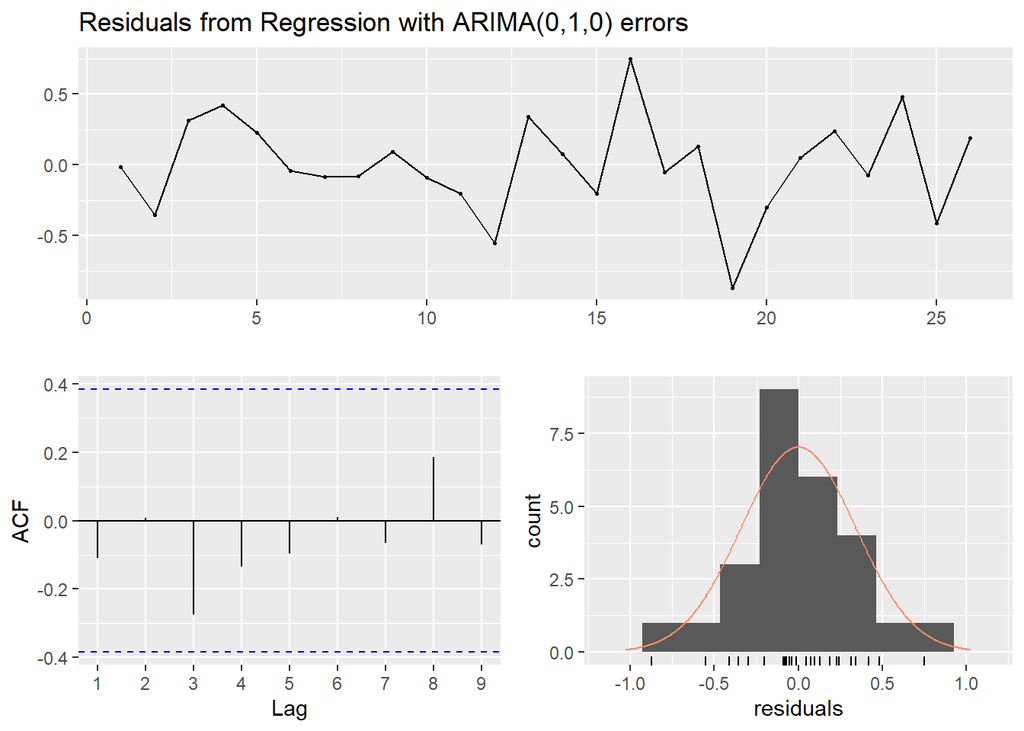

```
##
##  Ljung-Box test
##
## data:  Residuals from Regression with ARIMA(0,1,0) errors
## Q* = 3.6621, df = 3, p-value = 0.3003
##
## Model df: 2.   Total lags used: 5
```

```r
auto_arima_fit<- auto.arima(regression_data[,"unemployment_total"], xreg = as.matrix(regression_data[,"share_youth_NEET"]))
checkresiduals(auto_arima_fit)
```

### Modeling Formula

The full modeling equation ARMA(0,0) is:

$$unemployment'_t = unemployment_t - unemployment_{t-1}$$
$$youthNEET'_t = youthNEET_t - youthNEET_{t-1}$$

$$unemployment'_t = \mu + \beta_1youthNEET'_t + \epsilon_t \ \ \ \epsilon_t \sim_{iid} N(0, \sigma^2)$$

### Comparing Dynamic Regression Results with Classic Linear Regression

The ARMA model results in a slightly higher estimate, lower standard error, narrower confidence intervals, and a smaller pvalue for the predictor than the linear regression. The ARMA model results should be trusted more, because comparing the plots of the residuals, the assumptions were confirmed only for the ARMA model.

**Linear Model fit**

```r
library(lmtest)
summary(lm_fit)
```

```
##
## Call:
## lm(formula = unemployment_total ~ share_youth_NEET, data = regression_data)
##
## Residuals:
##     Min      1Q  Median      3Q     Max
## -1.5989 -0.7124 -0.1191  0.5843  1.5825
##
## Coefficients:
##                  Estimate Std. Error t value Pr(>|t|)
## (Intercept)       -7.2554     1.6938  -4.283 0.000257 ***
## share_youth_NEET   0.7733     0.1004   7.700 6.16e-08 ***
## ---
## Signif. codes:  0 '***' 0.001 '**' 0.01 '*' 0.05 '.' 0.1 ' ' 1
##
## Residual standard error: 0.906 on 24 degrees of freedom
## Multiple R-squared:  0.7119, Adjusted R-squared:  0.6999
## F-statistic: 59.29 on 1 and 24 DF,  p-value: 6.162e-08
```

```r
confint(lm_fit)
```

```
##                        2.5 %    97.5 %
## (Intercept)      -10.7512558 -3.759494
## share_youth_NEET   0.5660519  0.980601
```

**ARIMA(0,1,0) fit**

```r
coeftest(auto_arima_fit)
```

```
##
## z test of coefficients:
##
##       Estimate Std. Error z value Pr(>|z|)
## drift 0.131233   0.070913  1.8506  0.06423 .
## xreg  0.968157   0.077739 12.4539  < 2e-16 ***
## ---
## Signif. codes:  0 '***' 0.001 '**' 0.01 '*' 0.05 '.' 0.1 ' ' 1
```

```r
confint(auto_arima_fit)
```

```
##             2.5 %    97.5 %
## drift -0.00775443 0.2702204
## xreg   0.81579050 1.1205226
```

### Fitted Equation and Interpretations

The fitted ARMA equation is:
$$\hat{unemployment'} = 0.131 + 0.969youthNEET'$$
The interpretation of the predictor is as follows: for a 1% increase in consecutive yearly change in share of youth not in education or employment training, consecutive yearly change in unemployment rate increases by 0.969% on average.
The interpretation of the drift is as follows: the average consecutive yearly change in unemployment rate is 0.131%.

# Conclusions

## Forecasting Conclusions

The main conclusion of our forecasting exploration is that choosing a model for forecasting depends on how large the forecasting threshold is as well as what metric/ method and metric the model’s performance is to be evaluated under. For a forecasting threshold of 1 year using RMSE produced with cross validation, we would choose ARIMA(2, 1, 1). RMSE is chosen because MAPE selects forecasts that are underestimated on average. Considering Test RMSE the selected model would be ARIMA(0,2,1) which was verified to not be overdifferenced. When compared with the performance of lower compute methods like NAIVE, we can see a great improvement on performance.

## Regression Conclusions

For the regression of Unemployment ~ share of youth NEET the dynamic regression performed better according to the residual diagnostics. Our inference was also more trustworthy than that from the classical regression, acquiring narrower confidence intervals and a more significant p-value for our predictor. This led to our conclusion that there is evidence of a statistically significant relationship between the predictor and the response. However, this conclusion is matched with a thicc set of limitations. 1. The data set only has 26 observations  
2. We only used 1 predictor and future studies should include more controls for possible lurking variables (for example times of economic contraction being coded as structural breaks)

## Don’t Cry because its over, smile because it happened :)

[figure not shown]